# ACMG-ClinVar Markdown File

James Diao

October 1, 2016

> Working Directory: /Users/jamesdiao/Documents/Kohane_Lab/2016-paper-ACMG-penetrance

## Download, Transform, and Load Data

> 1. Access 1000 Genomes Phase 3 Populations Map from: ftp://ftp.1000genomes.ebi.ac.uk/vol1/ftp/release/20130502/integrated_call_samples_v3.20130502.ALL.panel

```
## # A tibble: 3 x 4
##    sample    pop super_pop gender
##    <fctr> <fctr>    <fctr> <fctr>
## 1 HG00096    GBR       EUR   male
## 2 HG00097    GBR       EUR female
## 3 HG00099    GBR       EUR female
```

> 2. Collect Population Data (link is down; data loaded from previous files via dput - August 2016)

```
## CHB JPT CHS CDX KHV CEU TSI FIN GBR IBS YRI LWK GWD MSL ESN ASW ACB MXL
## EAS EAS EAS EAS EAS EUR EUR EUR EUR EUR AFR AFR AFR AFR AFR AFR AFR AMR
## PUR CLM PEL GIH PJL BEB STU ITU
## AMR AMR AMR SAS SAS SAS SAS SAS
```

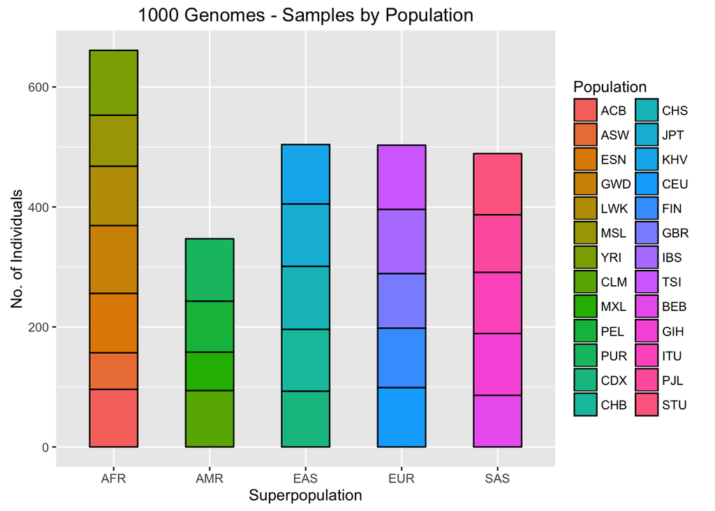

> 3. Scrape ACMG genes from ClinVar at: http://www.ncbi.nlm.nih.gov/clinvar/docs/acmg/

```
##  [1] "APC"     "MYH11"   "ACTA2"   "MYLK"    "TMEM43"  "DSP"     "PKP2"
##  [8] "DSG2"    "DSC2"    "BRCA1"   "BRCA2"   "SCN5A"   "RYR2"    "LMNA"
## [15] "MYBPC3"  "COL3A1"  "GLA"     "APOB"    "LDLR"    "MYH7"    "TPM1"
## [22] "PRKAG2"  "TNNI3"   "MYL3"    "MYL2"    "ACTC1"   "RET"     "PCSK9"
## [29] "TNNT2"   "TP53"    "TGFBR1"  "TGFBR2"  "SMAD3"   "KCNQ1"   "KCNH2"
## [36] "MLH1"    "MSH2"    "MSH6"    "PMS2"    "RYR1"    "CACNA1S" "FBN1"
## [43] "MEN1"    "MUTYH"   "NF2"     "SDHD"    "SDHAF2"  "SDHC"    "SDHB"
## [50] "STK11"   "PTEN"    "RB1"     "TSC1"    "TSC2"    "VHL"     "WT1"
```

> 4. Download ClinVar Interpretations
> 5. Download 1000 Genomes VCFs (pulled from working directory)
> 6. Import ExAC (downloaded by hand) and 1000 Genomes (supposedly downloaded just now)

## Analysis of Data

> 1. Merge ClinVar and 1000 Genomes

```
##  ClinVar    Patho in 1000G
##   116383    32908      147
```

```
##   1000G ClinVar   Patho
##  139335    4339     147
```

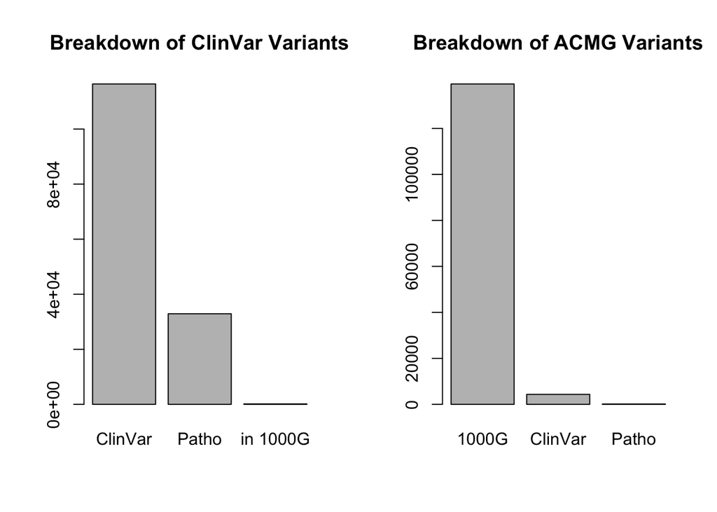

> 2. Gene distribution of ClinVar Pathogenic Variants in 1000 Genomes

```
##
##   SCN5A  MYBPC3    RYR1    LDLR    MYH7   KCNQ1    SDHB     RET   KCNH2
##      33      10       9       8       7       7       7       6       6
##   MUTYH     DSP    FBN1    DSG2     GLA     APC   MYH11  TMEM43    DSC2
##       6       4       4       3       3       2       2       2       2
##   BRCA1    APOB    MYL3    TP53    SDHD     RB1    MYLK    PKP2   BRCA2
##       2       2       2       2       2       2       1       1       1
##    RYR2  COL3A1    TPM1    MYL2   TNNT2  TGFBR2    MLH1    MSH2    MSH6
##       1       1       1       1       1       1       1       1       1
## CACNA1S    PTEN
##       1       1
```

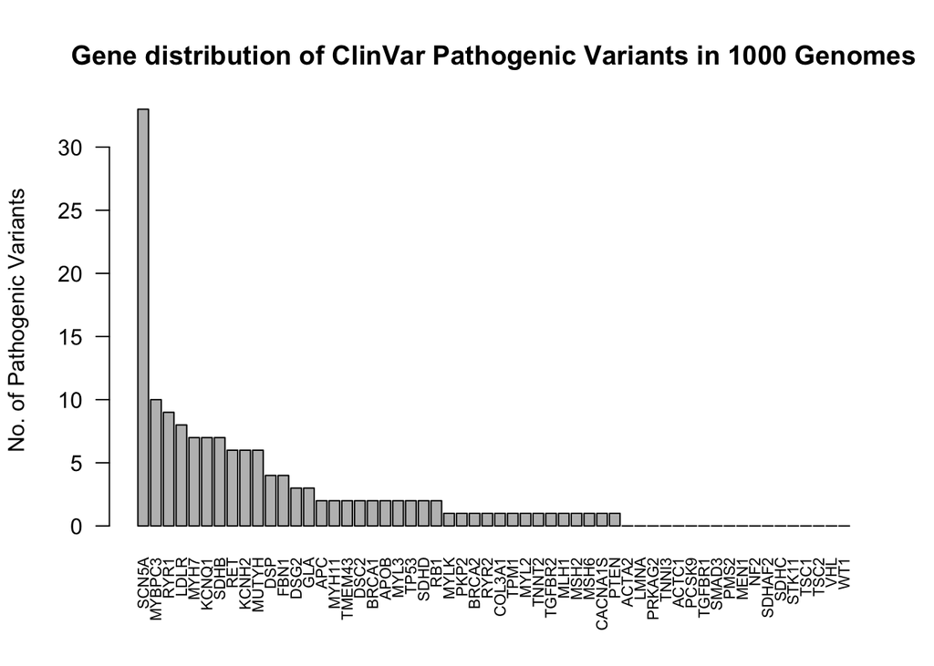

> 3. Overall Non-Reference Sites

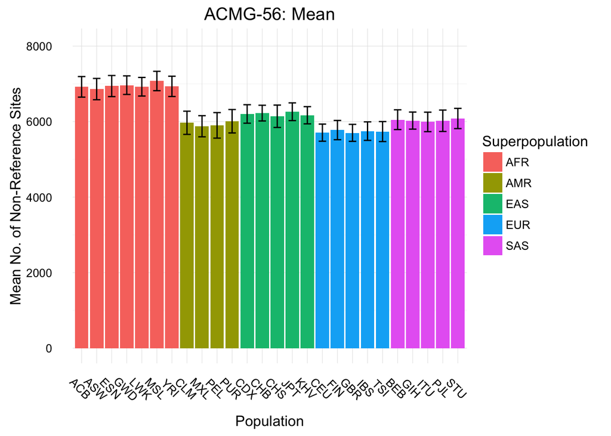

> 4. Pathogenic Non-Reference Sites

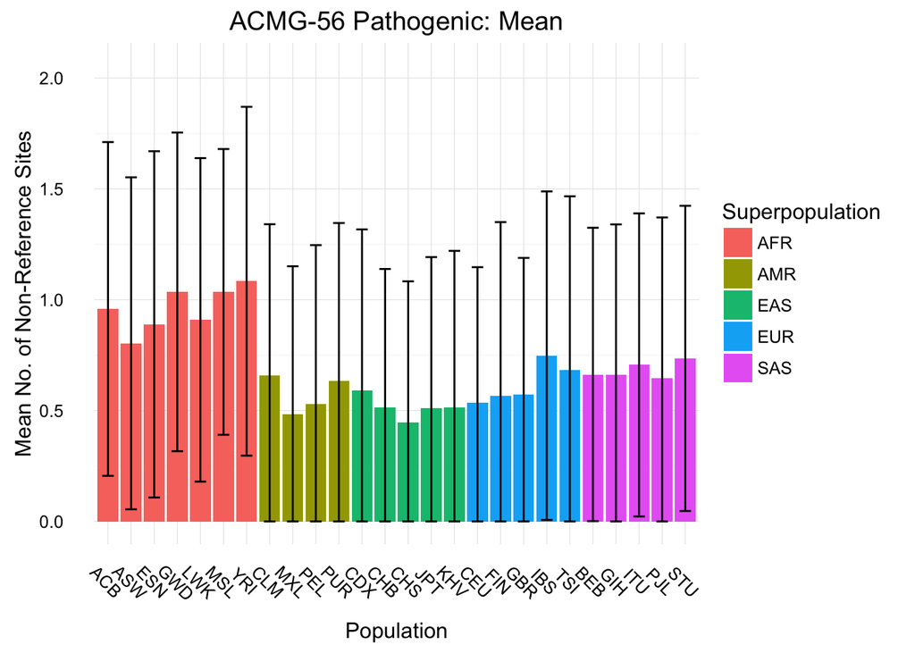

> 5. Fraction of 1000 Genomes Individuals with Pathogenic Sites

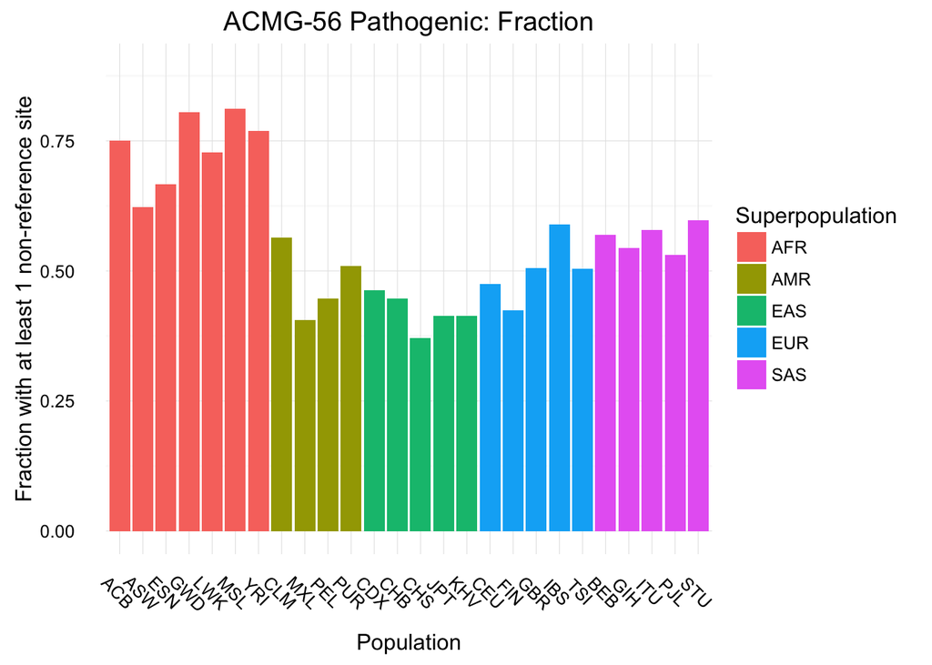

> 6. Ethnic Breakdown of 1000 Genomes Pathogenic Variants

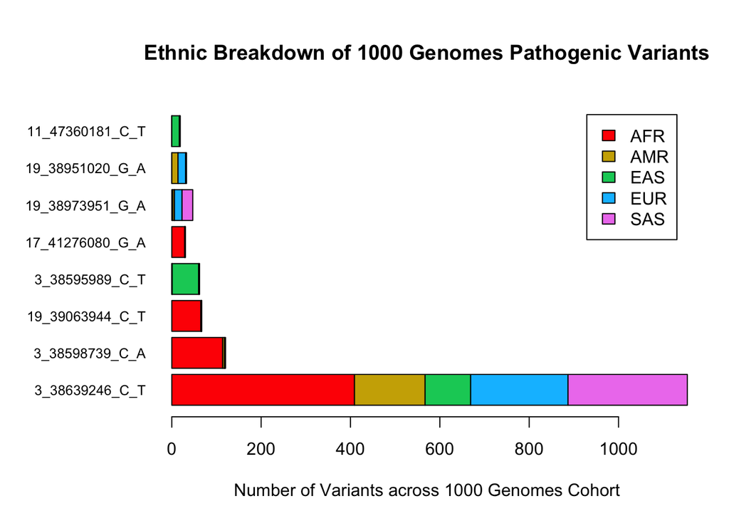

> 7. Test Statistics:

F-statistic/T-statistic: probability that the different groups are sampled from distributions with the same mean. These are from the Fraction plot, but can be replicated for non-reference means and pathogenic means as well.

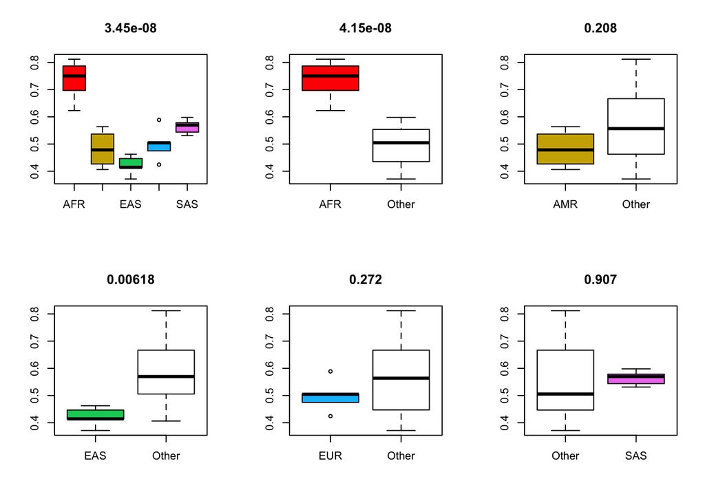

## Penetrance Estimates

> 1. Manually curated disease keywords from CLNDBN

```
##  [1] adenomatous                    aneurysm
##  [3] arrhythmogenic;dreifuss        breast;ovarian
##  [5] brugada;gardner                tachycardia
##  [7] dilated                        ehler
##  [9] fabry                          hypercholesterolemia
## [11] hypertrophic                   medullary
## [13] noncompaction                  Fraumeni
## [15] Loeys;Dietz                    QT
## [17] lynch;endometrial              hyperthermia
## [19] Marfan                         neoplasia;men2a
## [21] MYH;colon                      neurofibromatosis
## [23] paraganglioma;pheochromocytoma peutz;jeghers
## [25] pilomatrixoma                  Cowden;PTEN;hamartoma;Merkel
## [27] retinoblastoma                 tuberous
## [29] Hippel;Lindau                  Wilms
## 30 Levels: adenomatous aneurysm arrhythmogenic;dreifuss ... Wilms
```

> 2. Comparisons of allele frequencies by calculation method

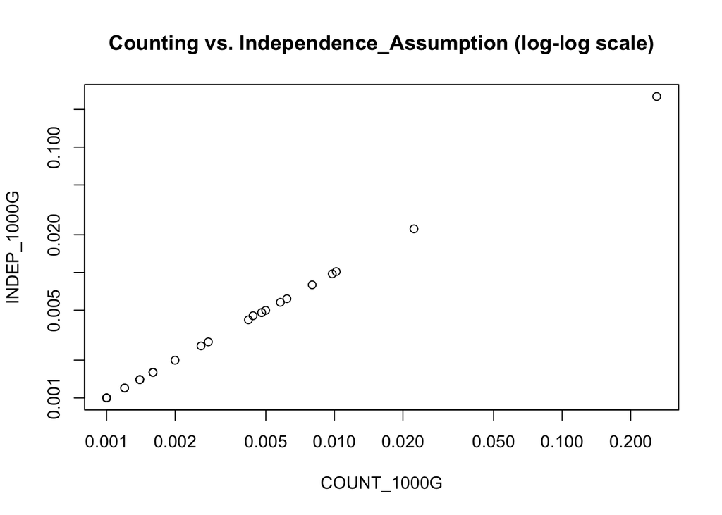

```
##             COUNT_1000G INDEP_1000G
## COUNT_1000G   1.0000000   0.9999975
## INDEP_1000G   0.9999975   1.0000000
```

> 3. What fraction of people have an LP/P mutation in each disease category?

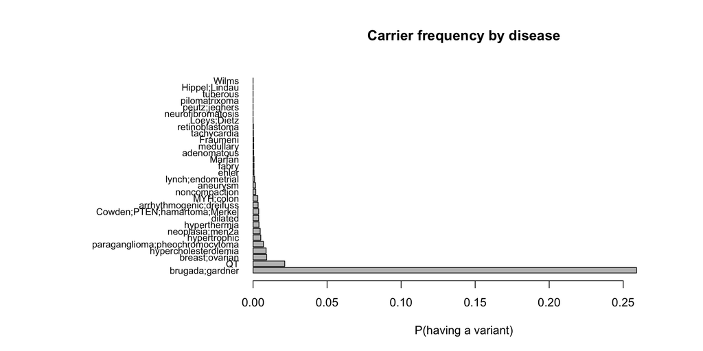

> 4. Penetrance as a function of allelic heterogeneity: P(V|D) = 0.001, 0.02, 0.5

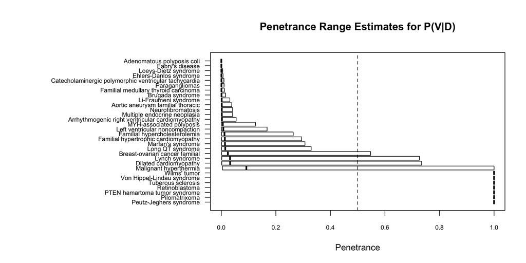

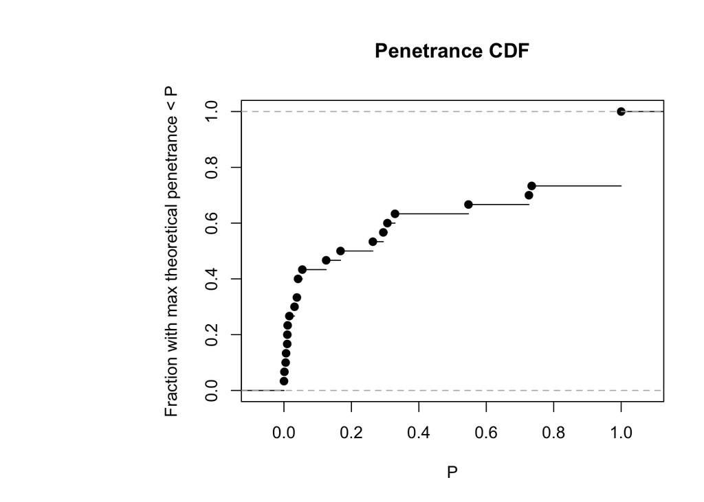

> 5. Empirical prevalence ranges

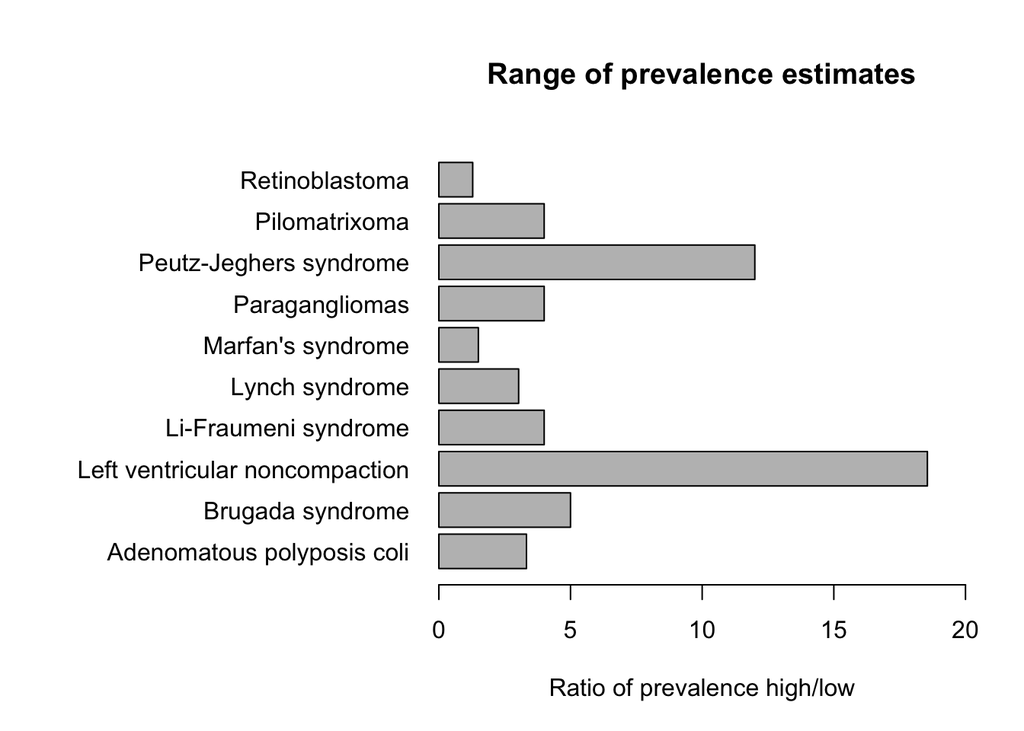

> 6. Penetrance as a function of prevalence - P(V|D) set to 0.1

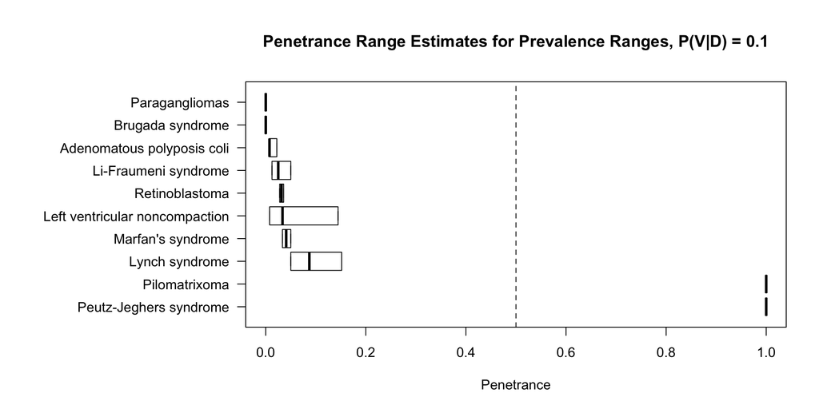

> 7. Penetrance as a function of prevalence - P(V|D) set to 1

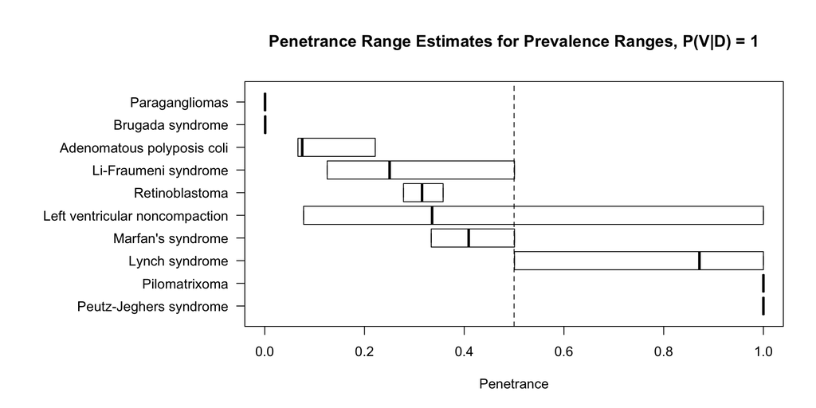